# 건축 소요기간 통계 (2025년 12월 데이터 기준)

## 2. 건축 소요기간 통계

### 데이터 전처리 조건:

- 집계대상: 기본개요
- 기간(착공일, 준공일): **최근 10년 (2015 ~ 2024년)**
- 건축행위: **신축** (건축: 건축_구분_코드 0100, 주택: 용도_코드 부여)
  - 주택의 경우 아파트 단지의 최초 신축만 구분할 수 없음. 행위개요 테이블에서도 나타나지 않음. 주소도 블록 주소에서 도로명 주소로 바뀌기 때문에 주소 기준 구분도 어려움. 기본개요 용도_코드 부여 여부로 판단함. (용도_코드가 부여된 = 최초 신축 시, 연면적 사용 가능)
- 연면적: **30,000,000㎡ 미만** (명백한 오류 데이터 제외)
- 착공일 추정: 준공일(사용승인일/사용검사일)이 있는 경우 실제 착공일(건축: 실제 착공 일, 주택: 착공 일) → 착공 연기일(건축) → 착공 예정일(건축, 주택) 순으로 착공일 추정

```python
# 건축인허가 신축 데이터 필터링 및 소요기간 계산
sql_건축 = f"""
WITH base AS (
    SELECT
        CONCAT('건축', "관리_허가대장_PK") AS pk,
        "시군구_코드",
        "주_용도_코드",
        "주_용도_코드_명",
        "건축_구분_코드",
        "건축_구분_코드_명",
        CAST(NULLIF("연면적(㎡)", 0) AS DOUBLE) AS 연면적,
        "건축_허가_일" AS 허가일,
        "착공_예정_일",
        "착공_연기_일",
        "실제_착공_일",
        "사용승인_일" AS 준공일,
        CASE
            WHEN "사용승인_일" IS NOT NULL AND TRIM("사용승인_일") != ''
                THEN COALESCE(NULLIF(TRIM("실제_착공_일"), ''), NULLIF(TRIM("착공_연기_일"), ''), NULLIF(TRIM("착공_예정_일"), ''))
            ELSE TRIM("실제_착공_일")
        END AS 착공일
    FROM read_parquet('{path_건축.as_posix()}')
    WHERE "건축_구분_코드" IN ('0100')  -- 신축만
      AND CAST(NULLIF("연면적(㎡)", 0) AS DOUBLE) < 30000000  -- 30_000_000 ㎡ 이상 극단치 제외
)
SELECT
    pk,
    허가일,
    착공일,
    준공일,
    LEFT(TRIM(착공일), 4) AS 착공_년,
    LEFT(TRIM(준공일), 4) AS 준공_년,
    LEFT(TRIM(시군구_코드), 2) AS 시도_코드,
    주_용도_코드,
    주_용도_코드_명,
    연면적,
    date_diff('day', try_strptime(허가일, '%Y%m%d'), try_strptime(착공일, '%Y%m%d')) AS 허가착공_기간,
    date_diff('day', try_strptime(착공일, '%Y%m%d'), try_strptime(준공일, '%Y%m%d')) AS 착공준공_기간,
    date_diff('day', try_strptime(허가일, '%Y%m%d'), try_strptime(준공일, '%Y%m%d')) AS 허가준공_기간
FROM base
"""

rel_건축_duration = con.sql(sql_건축)
print(f"건축인허가 전체 데이터 건수: {len(rel_건축_duration.df()):,}")


def filter_date_range(
    rel: duckdb.DuckDBPyRelation, col: str, lower: str, upper: str
) -> duckdb.DuckDBPyRelation:
    """
    Filters a DuckDB relation by a date range and length requirement.
    Equivalent to:
    WHERE {col} >= '{lower}' AND {col} <= '{upper}' AND LENGTH(TRIM({col})) = 8
    """
    condition = f"{col} >= '{lower}' AND {col} <= '{upper}' AND LENGTH(TRIM({col})) = 8"
    return rel.filter(condition)


print(
    f"건축인허가 착공일 기준 대상 건수: {len(filter_date_range(rel_건축_duration, '착공일', lower, upper).df()):,}"
)
print(
    f"건축인허가 준공일 기준 대상 건수: {len(filter_date_range(rel_건축_duration, '준공일', lower, upper).df()):,}"
)
```

```
건축인허가 전체 데이터 건수: 2,821,956
건축인허가 착공일 기준 대상 건수: 952,396
건축인허가 준공일 기준 대상 건수: 869,136
```

```python
# 주택인허가 신축 데이터 필터링 및 소요기간 계산
sql_주택 = f"""
WITH base AS (
    SELECT
        CONCAT('주택', "관리_주택대장_PK") AS pk,
        "시군구_코드",
        "용도_코드" AS 주_용도_코드,
        "용도_코드_명" AS 주_용도_코드_명,
        '0100' AS 건축_구분_코드,
        '신축' AS 건축_구분_코드_명,
        CAST(NULLIF("연면적(㎡)", 0) AS DOUBLE) AS 연면적,
        "승인_일" AS 허가일,
        "착공_예정_일",
        "착공_일" AS 원_기재_착공_일,
        "사용_검사_일" AS 준공일,
        CASE
            WHEN "사용_검사_일" IS NOT NULL AND TRIM("사용_검사_일") != ''
                THEN COALESCE(NULLIF(TRIM("착공_일"), ''), NULLIF(TRIM("착공_예정_일"), ''))
            ELSE TRIM("착공_일")
        END AS 착공일
    FROM read_parquet('{path_주택.as_posix()}')
    WHERE "용도_코드" IS NOT NULL  -- 주택인허가에서의 신축 추정
      AND CAST(NULLIF("연면적(㎡)", 0) AS DOUBLE) < 30000000  -- 30_000_000 ㎡ 이상 극단치 제외
)
SELECT
    pk,
    허가일,
    착공일,
    준공일,
    LEFT(TRIM(착공일), 4) AS 착공_년,
    LEFT(TRIM(준공일), 4) AS 준공_년,
    LEFT(TRIM(시군구_코드), 2) AS 시도_코드,
    주_용도_코드,
    주_용도_코드_명,
    연면적,
    date_diff('day', try_strptime(허가일, '%Y%m%d'), try_strptime(착공일, '%Y%m%d')) AS 허가착공_기간,
    date_diff('day', try_strptime(착공일, '%Y%m%d'), try_strptime(준공일, '%Y%m%d')) AS 착공준공_기간,
    date_diff('day', try_strptime(허가일, '%Y%m%d'), try_strptime(준공일, '%Y%m%d')) AS 허가준공_기간
FROM base
"""

rel_주택_duration = con.sql(sql_주택)
print(f"주택인허가 분석 대상 건수: {len(rel_주택_duration):,}")

print(
    f"주택인허가 착공일 기준 대상 건수: {len(filter_date_range(rel_주택_duration, '착공일', lower, upper).df()):,}"
)
print(
    f"주택인허가 준공일 기준 대상 건수: {len(filter_date_range(rel_주택_duration, '준공일', lower, upper).df()):,}"
)
```

```
주택인허가 분석 대상 건수: 29,955
주택인허가 착공일 기준 대상 건수: 4,691
주택인허가 준공일 기준 대상 건수: 5,732
```

```python
# 통합 데이터 생성
df_total = pd.concat(
    [rel_건축_duration.df(), rel_주택_duration.df()], ignore_index=True
)
```

```python
# 기간 오류 데이터 확인

# 오류 데이터(마이너스 기간 등) 필터링
valid_all_mask = (
    (df_total["허가착공_기간"] >= 0)
    & (df_total["착공준공_기간"] >= 0)
    & (df_total["허가준공_기간"] >= 0)
)
df_valid_all = df_total[valid_all_mask].copy()

print(f"유효한 소요기간 산출 건수: {len(df_valid_all):,} (총 {len(df_total):,} 건 중)")

# 음수 데이터 (하나라도)
invalid_mask = (
    (df_total["허가착공_기간"] < 0)
    | (df_total["착공준공_기간"] < 0)
    | (df_total["허가준공_기간"] < 0)
)
df_invalid = df_total[invalid_mask].copy()

# 누락 데이터 (하나라도)
missing_mask = (
    df_total["허가착공_기간"].isna()
    | df_total["착공준공_기간"].isna()
    | df_total["허가준공_기간"].isna()
)
df_missing = df_total[missing_mask].copy()

print(f"오류 데이터 건수: {len(df_invalid):,} (총 {len(df_total):,} 건 중)")
print(f"누락 데이터 건수: {len(df_missing):,} (총 {len(df_total):,} 건 중)")

df_invalid_and_missing = df_total[invalid_mask & missing_mask].copy()

print(
    f"오류이면서 동시에 누락인 데이터 건수: {len(df_invalid_and_missing):,} (총 {len(df_total):,} 건 중)"
)

print(
    f"""Check if {len(df_total) ==
len(df_valid_all) + len(df_invalid) + len(df_missing) - len(df_invalid_and_missing)
=}"""
)

# 오류 데이터 일부 표시
print("\n오류 데이터:")
print(df_invalid.head())

# 누락 데이터 일부 표시
print("\n누락 데이터:")
print(df_missing.head())
```

```
유효한 소요기간 산출 건수: 2,133,982 (총 2,851,911 건 중)
오류 데이터 건수: 10,220 (총 2,851,911 건 중)
누락 데이터 건수: 709,190 (총 2,851,911 건 중)
오류이면서 동시에 누락인 데이터 건수: 1,481 (총 2,851,911 건 중)
Check if len(df_total) ==
len(df_valid_all) + len(df_invalid) + len(df_missing) - len(df_invalid_and_missing)
=True

오류 데이터:
                pk    허가일    착공일    준공일 착공_년 준공_년 시도_코드  \
399   건축10568315  19970529  19950601  19951101    1995    1995        28
443  건축105612251  20001130  20001122  20010514    2000    2001        28
657   건축10613560  20011012  20001110  20010514    2000    2001        28
906    건축1058949  20000904  20000106       NaN    2000     NaN        28
948  건축105612207  20001101  20001025  20010410    2000    2001        28

    주_용도_코드    주_용도_코드_명  연면적  허가착공_기간  착공준공_기간  \
399        02000           공동주택  530.75           -728            153
443        02000           공동주택  645.30             -8            173
657        03000  제1종근린생활시설   72.00           -336            185
906          NaN                NaN   87.76           -242           <NA>
948        02000           공동주택  651.38             -7            167

     허가준공_기간
399           -575
443            165
657           -151
906           <NA>
948            160

누락 데이터:
                           pk    허가일 착공일 준공일 착공_년 준공_년  \
0  건축1000000000000000001810  20220425    NaN    NaN     NaN     NaN
1  건축1000000000000000230507  20230215    NaN    NaN     NaN     NaN
2  건축1000000000000000018144  20220805    NaN    NaN     NaN     NaN
6                건축10551234  20030715    NaN    NaN     NaN     NaN
8                 건축1055794  20020102    NaN    NaN     NaN     NaN

  시도_코드 주_용도_코드    주_용도_코드_명  연면적  허가착공_기간  \
0        28        01000           단독주택  226.10           <NA>
1        31        03000  제1종근린생활시설  483.31           <NA>
2        28        04000  제2종근린생활시설  195.50           <NA>
6        28        04000  제2종근린생활시설  127.68           <NA>
8        28        04000  제2종근린생활시설  136.50           <NA>

   착공준공_기간  허가준공_기간
0           <NA>           <NA>
1           <NA>           <NA>
2           <NA>           <NA>
6           <NA>           <NA>
8           <NA>           <NA>
```

### 최근 10년 연도별 중위 소요기간 (단위: 일)

```python
# 착공일 기준 최근 10년 데이터
df_착공10년 = df_total[
    (df_total["착공_년"] >= lower[:4]) & (df_total["착공_년"] <= upper[:4])
]
print(f"착공일 기준 최근 10년 데이터 건수: {len(df_착공10년):,}")

# 준공일 기준 최근 10년 데이터
df_준공10년 = df_total[
    (df_total["준공_년"] >= lower[:4]) & (df_total["준공_년"] <= upper[:4])
]
print(f"준공일 기준 최근 10년 데이터 건수: {len(df_준공10년):,}")
```

```
착공일 기준 최근 10년 데이터 건수: 957,089
준공일 기준 최근 10년 데이터 건수: 874,872
```

```python
# 착공일/준공일 기준 최근 10년 연도별 중위 소요기간
# 허가착공 기간
print("허가착공 기간: 착공일 기준")
stat_by_year_허가착공 = (
    df_착공10년[df_착공10년["허가착공_기간"] >= 0]
    .groupby("착공_년")[["허가착공_기간"]]
    .median()
    .astype("Int64")  # cast median output(float64) to nullable int type
)

# 착공준공 기간
print("착공준공 기간: 준공일 기준")
stat_by_year_착공준공 = (
    df_준공10년[df_준공10년["착공준공_기간"] >= 0]
    .groupby("준공_년")[["착공준공_기간"]]
    .median()
    .astype("Int64")  # cast median output(float64) to nullable int type
)

# 허가준공 기간
print("허가준공 기간: 준공일 기준")
stat_by_year_허가준공 = (
    df_준공10년[df_준공10년["허가준공_기간"] >= 0]
    .groupby("준공_년")[["허가준공_기간"]]
    .median()
    .astype("Int64")  # cast median output(float64) to nullable int type
)

stat_by_year_허가착공.index.name = "연도"
stat_by_year_착공준공.index.name = "연도"
stat_by_year_허가준공.index.name = "연도"

stat_by_year = stat_by_year_허가착공.join(stat_by_year_착공준공, how="outer").join(
    stat_by_year_허가준공, how="outer"
)

print(stat_by_year)
stat_by_year.dtypes
```

```
허가착공 기간: 착공일 기준
착공준공 기간: 준공일 기준
허가준공 기간: 준공일 기준
      허가착공_기간  착공준공_기간  허가준공_기간
연도
2015             14            162            190
2016             17            178            208
2017             23            191            228
2018             32            196            245
2019             35            196            262
2020             35            191            256
2021             37            196            253
2022             43            217            287
2023             51            251            340
2024             50            238            337
```

```
허가착공_기간    Int64
착공준공_기간    Int64
허가준공_기간    Int64
dtype: object
```

```python
# 허가준공 기간 분포 대푯값

# 허가준공 histogram using plt, with mean, median, mode, min, max

# data
df_dist = df_준공10년["허가준공_기간"].dropna()

# Calculate statistics
mean_val = df_dist.mean()
median_val = df_dist.median()
mode_val = df_dist.mode().iloc[0]
min_val = df_dist.min()
max_val = df_dist.max()

# print values
print(f"Mean: {mean_val}")
print(f"Median: {median_val}")
print(f"Mode: {mode_val}")
print(f"Min: {min_val}")
print(f"Max: {max_val}")
```

```
Mean: 430.1716276617691
Median: 244.0
Mode: 168
Min: -32780
Max: 301234
```

```python
# 허가준공 301234인 데이터 확인
df_301234 = df_total[df_total["허가준공_기간"] == 301234].copy()

print(df_301234.head())
print(f"허가준공 301234인 데이터 건수: {len(df_301234):,}")
```

```
                       pk    허가일 착공일    준공일 착공_년 준공_년  \
820167  건축1018100042115  11900417    NaN  20150116     NaN    2015

       시도_코드 주_용도_코드 주_용도_코드_명  연면적  허가착공_기간  \
820167        11        01000        단독주택  232.89           <NA>

        착공준공_기간  허가준공_기간
820167           <NA>         301234
허가준공 301234인 데이터 건수: 1
```

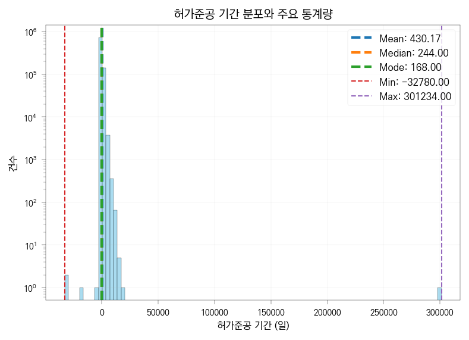

```python
# Create histogram with vertical lines

# create new Figure
plt.figure()
# log scale y axis
plt.yscale("log")
# create histogram
plt.hist(
    df_dist,
    bins=100,
    alpha=0.7,
    color="skyblue",
    edgecolor="black",
)

# Add vertical lines for mean, median, and mode
# get colors from tab10 colormap for vertical lines
colors = plt.get_cmap("tab10").colors

plt.axvline(
    mean_val,
    color=colors[0],
    linestyle="dashed",
    linewidth=2,
    label=f"Mean: {mean_val:.2f}",
)
plt.axvline(
    median_val,
    color=colors[1],
    linestyle="dashed",
    linewidth=2,
    label=f"Median: {median_val:.2f}",
)
plt.axvline(
    mode_val,
    color=colors[2],
    linestyle="dashed",
    linewidth=2,
    label=f"Mode: {mode_val:.2f}",
)
plt.axvline(
    min_val,
    color=colors[3],
    linestyle="dashed",
    linewidth=1,
    label=f"Min: {min_val:.2f}",
)
plt.axvline(
    max_val,
    color=colors[4],
    linestyle="dashed",
    linewidth=1,
    label=f"Max: {max_val:.2f}",
)

# Add labels and title
plt.xlabel("허가준공 기간 (일)")
plt.ylabel("건수")
plt.title("허가준공 기간 분포와 주요 통계량")
plt.legend(loc="upper right")  # make it at top right
plt.grid(True, alpha=0.3)

# save
dir_to = base_dir / "results" / "stat_construction_duration"
dir_to.mkdir(parents=True, exist_ok=True)

plt.savefig(dir_to / "허가준공_기간_분포와_주요_통계량.png")

# Show the plot
plt.show()
```

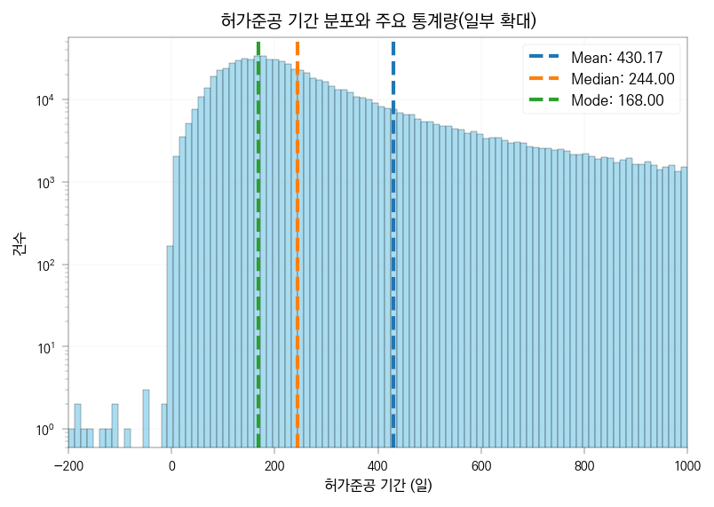

```python
# Create zoomed-in histogram

# create new Figure
plt.figure()
# zoom in x range to show difference between mean, median, and mode
plt.xlim(-200, 1000)
# log scale y axis
plt.yscale("log")
# create histogram
plt.hist(
    df_dist,
    bins=100,
    range=(-200, 1000),
    alpha=0.7,
    color="skyblue",
    edgecolor="black",
)

# Add vertical lines for mean, median, and mode
# get colors from tab10 colormap for vertical lines
colors = plt.get_cmap("tab10").colors

plt.axvline(
    mean_val,
    color=colors[0],
    linestyle="dashed",
    linewidth=2,
    label=f"Mean: {mean_val:.2f}",
)
plt.axvline(
    median_val,
    color=colors[1],
    linestyle="dashed",
    linewidth=2,
    label=f"Median: {median_val:.2f}",
)
plt.axvline(
    mode_val,
    color=colors[2],
    linestyle="dashed",
    linewidth=2,
    label=f"Mode: {mode_val:.2f}",
)

# Add labels and title
plt.xlabel("허가준공 기간 (일)")
plt.ylabel("건수")
plt.title("허가준공 기간 분포와 주요 통계량(일부 확대)")
plt.legend(loc="upper right")  # make it at top right
plt.grid(True, alpha=0.3)

# save
dir_to = base_dir / "results" / "stat_construction_duration"
dir_to.mkdir(parents=True, exist_ok=True)

plt.savefig(dir_to / "허가준공_기간_분포와_주요_통계량_zoom.png")

# Show the plot
plt.show()
```